# Análise Pokemon

Eduardo, Itamar e Rodrigo

### A base

O autor do *dataset* propõe diversas análises, dentre elas apresentaremos:

- Qual a relação entre altura e peso com as estatísticas básicas do Pokémon?
- Qual é o tipo mais forte e o mais fraco?

Pois bem, vamos começar as análises. O primeiro posso é importar os dados no R para trabalharmos

```r
library(tidyverse)

dados <- read_csv("pokemon.csv")
head(dados)
```

| abilities | against_bug | against_dark | against_dragon | against_electric | against_fairy | against_fight | against_fire | against_flying | against_ghost | against_grass | against_ground | against_ice | against_normal | against_poison | against_psychic | against_rock | against_steel | against_water | attack | base_egg_steps | base_happiness | base_total | capture_rate | classfication | defense | experience_growth | height_m | hp | japanese_name | … |
| --- | --- | --- | --- | --- | --- | --- | --- | --- | --- | --- | --- | --- | --- | --- | --- | --- | --- | --- | --- | --- | --- | --- | --- | --- | --- | --- | --- | --- | --- | --- |
| ['Overgrow', 'Chlorophyll'] | 1.00 | 1 | 1 | 0.5 | 0.5 | 0.5 | 2.0 | 2 | 1 | 0.25 | 1 | 2.0 | 1 | 1 | 2 | 1 | 1.0 | 0.5 | 49 | 5120 | 70 | 318 | 45 | Seed Pokémon | 49 | 1059860 | 0.7 | 45 | Fushigidane | … |
| ['Overgrow', 'Chlorophyll'] | 1.00 | 1 | 1 | 0.5 | 0.5 | 0.5 | 2.0 | 2 | 1 | 0.25 | 1 | 2.0 | 1 | 1 | 2 | 1 | 1.0 | 0.5 | 62 | 5120 | 70 | 405 | 45 | Seed Pokémon | 63 | 1059860 | 1.0 | 60 | Fushigisou | … |
| ['Overgrow', 'Chlorophyll'] | 1.00 | 1 | 1 | 0.5 | 0.5 | 0.5 | 2.0 | 2 | 1 | 0.25 | 1 | 2.0 | 1 | 1 | 2 | 1 | 1.0 | 0.5 | 100 | 5120 | 70 | 625 | 45 | Seed Pokémon | 123 | 1059860 | 2.0 | 80 | Fushigibana | … |
| ['Blaze', 'Solar Power'] | 0.50 | 1 | 1 | 1.0 | 0.5 | 1.0 | 0.5 | 1 | 1 | 0.50 | 2 | 0.5 | 1 | 1 | 1 | 2 | 0.5 | 2.0 | 52 | 5120 | 70 | 309 | 45 | Lizard Pokémon | 43 | 1059860 | 0.6 | 39 | Hitokage | … |
| ['Blaze', 'Solar Power'] | 0.50 | 1 | 1 | 1.0 | 0.5 | 1.0 | 0.5 | 1 | 1 | 0.50 | 2 | 0.5 | 1 | 1 | 1 | 2 | 0.5 | 2.0 | 64 | 5120 | 70 | 405 | 45 | Flame Pokémon | 58 | 1059860 | 1.1 | 58 | Lizardo | … |
| ['Blaze', 'Solar Power'] | 0.25 | 1 | 1 | 2.0 | 0.5 | 0.5 | 0.5 | 1 | 1 | 0.25 | 0 | 1.0 | 1 | 1 | 1 | 4 | 0.5 | 2.0 | 104 | 5120 | 70 | 634 | 45 | Flame Pokémon | 78 | 1059860 | 1.7 | 78 | Lizardon | … |

### Análises prévias

Vamos agora fazer uma análise prévia da base. Abaixo apresenta-se o número de pokémons por geração:

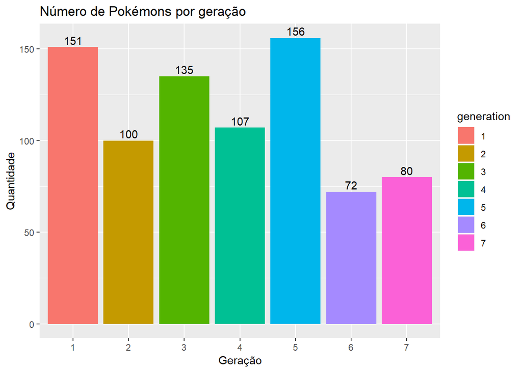

```r
dados %>%
  mutate(generation = factor(generation)) %>%
  ggplot(aes(x = generation, fill = generation)) +
  geom_bar() +
  geom_text(stat = "count",mapping = aes(label=..count..), vjust=-0.3) +
  labs(title = "Número de Pokémons por geração", x = "Geração", y = "Quantidade")
```

Podemos observar a primeira ~e clássica~ geração com seus 151 pokémon e as gerações 6 e 7 que possuem os menores números de pokémons…

A seguir, apresentamos a proporção de pokémons lendários:

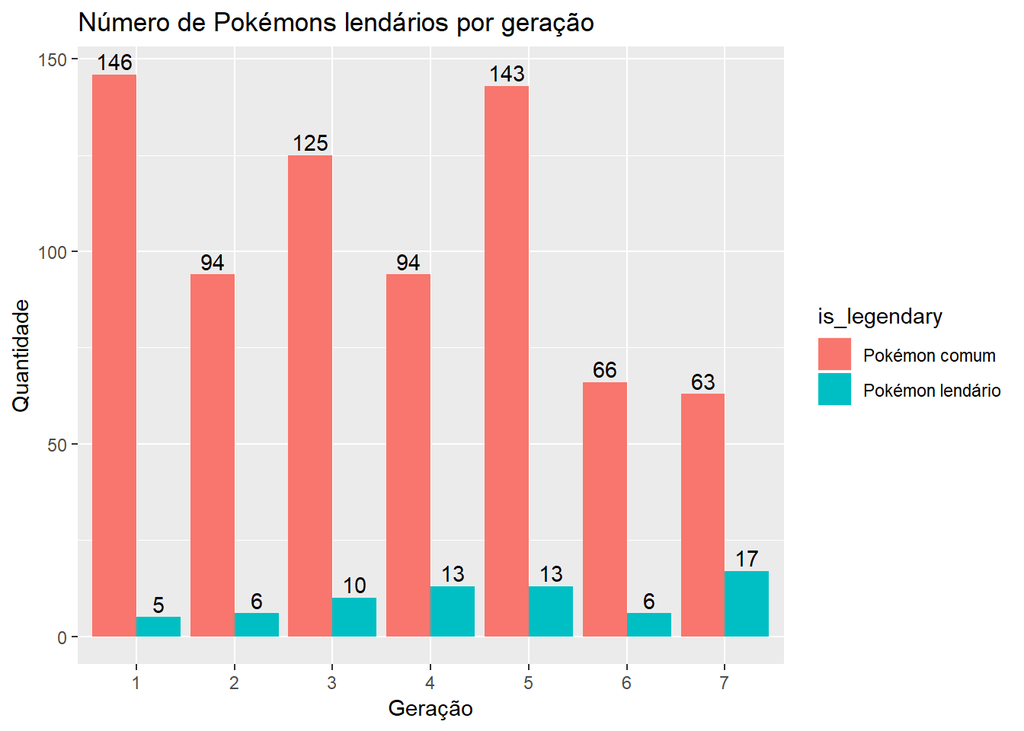

```r
dados %>%
  mutate(generation = factor(generation),
         is_legendary = ifelse(is_legendary == 1, "Pokémon lendário", "Pokémon comum")) %>%
  group_by(generation, is_legendary) %>%
  summarise(qtd = n()) %>%
  ggplot(aes(x = generation, fill = is_legendary, y = qtd)) +
  geom_bar(stat = "identity", position = position_dodge()) +
  geom_text(aes(label = qtd), vjust=-0.3, position = position_dodge(0.9)) +
  labs(title = "Número de Pokémons lendários por geração", x = "Geração", y = "Quantidade")
```

Agora vamos verificar o número de pokémons por tipo:

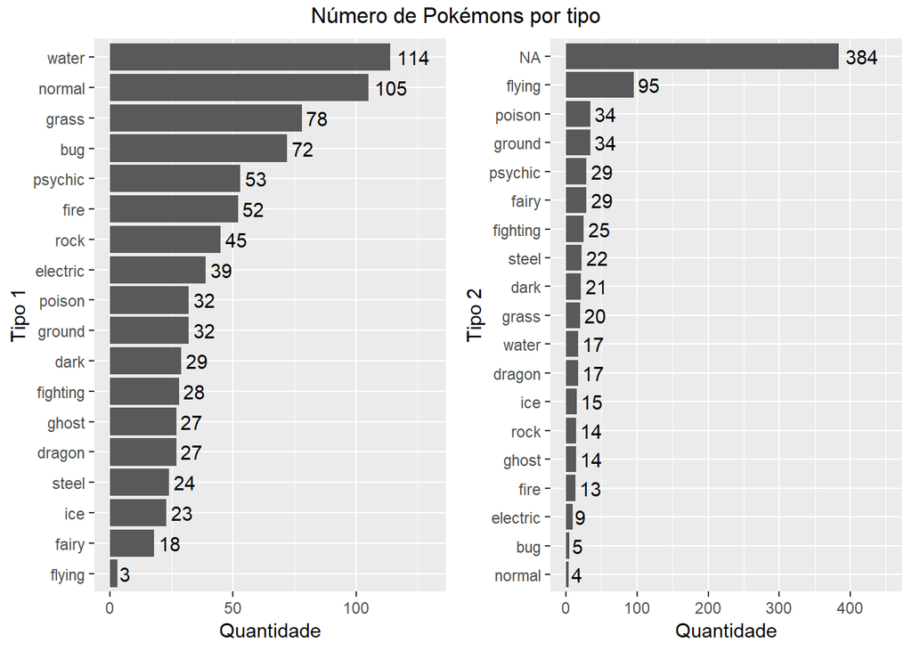

```r
library(gridExtra)

p1 <- dados %>%
  group_by(type1) %>%
  summarise(qtd = n()) %>%
  ggplot(aes(x = reorder(type1, qtd), y = qtd)) +
  geom_bar(stat = "identity") +
  coord_flip() +
  geom_text(aes(label = qtd), hjust = -0.2) +
  labs(x = "Tipo 1", y = "Quantidade") +
  ylim(0, 130)

p2 <- dados %>%
  group_by(type2) %>%
  summarise(qtd = n()) %>%
  ggplot(aes(x = reorder(type2, qtd), y = qtd)) +
  geom_bar(stat = "identity") +
  coord_flip() +
  geom_text(aes(label = qtd), hjust = -0.2) +
  labs(x = "Tipo 2", y = "Quantidade") +
  ylim(0, 450)

grid.arrange(p1, p2, ncol=2, top = "Número de Pokémons por tipo")
```

Analisando o primeiro tipo de pokémon, vemos que o preominante é água, seguido por normal, grama e inseto. Os tipos menos comuns são voados, fada e gelo.

Observando o segundo gráfico (da direita), podemos identificar que 384 pokémon não apresenta um segundo tipo e que o tipo voador é o segundo tipo com maior frequência.

### Qual a relação entre altura e peso com as estatísticas básicas do pokémon?

Vamos agora responder a primeira pergunta do autor. Para isso, abaixo apresentamos uma matriz de correlação entre as variáveis selecionadas.

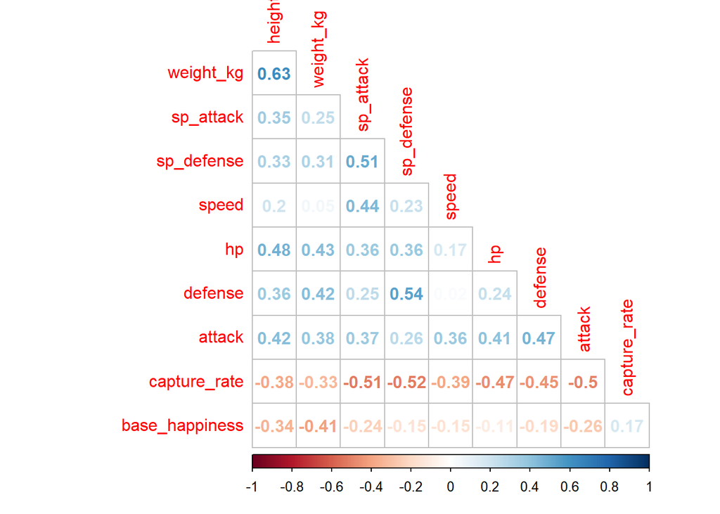

```r
library(corrplot)

dados %>%
  mutate(capture_rate = as.numeric(capture_rate)) %>%
  select(height_m, weight_kg, sp_attack, sp_defense, speed, hp, defense, attack,
         capture_rate, base_happiness) %>%
  drop_na() %>%
  cor() %>%
  corrplot(method = "number", type = "lower", diag = F)
```

Podemos observar que a altura é correlacionada com os pontos de vida do pokémon, bem como o ataque (ambos com coeficiente de correlação acima de 0,4). Já o peso, além dos pontos de vida, correlaciona também com os pontos de defesa. Olha que legal! altura determina o poder de ataque, enquanto o peso determina o poder de defesa. Enquanto o Onix ataca o Snorlax fica de boa só segurando a onda…

Apesar de não fazer parte do escopo inicial, a matriz de correlaçaõ trouxe também outras informações interessantes: A chace de capturar um pokémon é inversamente proporcional às características básicas e ela aumenta com base na felicidade dele (^^)

### Qual é o tipo mais forte e o mais fraco?

E agora, qual o tipo de pokémon que eu tenho que ter pra bater em todo mundo? Abaixo apresentamos uma tabela com o dano médio de cada tipo de pokémon com cada cada um dos tipos apresetados.

```r
dano_medio <- dados %>%
  select(type1, against_bug, against_dark, against_dragon, against_electric, against_fairy,
         against_fight, against_fire, against_flying, against_ghost, against_grass, against_ground,
         against_ice, against_normal, against_poison, against_psychic, against_rock, against_steel,
         against_water) %>%
  group_by(type1) %>%
  summarise_all(mean) %>%
  rowwise() %>%
  mutate(geral = mean(against_bug:against_water)) %>%
  arrange(-geral)

dano_medio
```

| type1 | against_bug | against_dark | against_dragon | against_electric | against_fairy | against_fight | against_fire | against_flying | against_ghost | against_grass | against_ground | against_ice | against_normal | against_poison | against_psychic | against_rock | against_steel | against_water | geral |
| --- | --- | --- | --- | --- | --- | --- | --- | --- | --- | --- | --- | --- | --- | --- | --- | --- | --- | --- | --- |
| dark | 1.7241379 | 0.5344828 | 1.1034483 | 1.1034483 | 2.2758621 | 1.9655172 | 1.0344828 | 1.0344828 | 0.5517241 | 0.7758621 | 0.9655172 | 1.2068966 | 0.9310345 | 0.9137931 | 0.0000000 | 1.2413793 | 1.0000000 | 1.0000000 | 1.7241379 |
| psychic | 1.7169811 | 1.9433962 | 0.8773585 | 1.1037736 | 1.0000000 | 0.4339623 | 1.0283019 | 1.0283019 | 2.0754717 | 0.9150943 | 0.9150943 | 1.1132075 | 0.9528302 | 1.0943396 | 0.5047170 | 1.1132075 | 1.0943396 | 1.0094340 | 1.7169811 |
| ground | 1.0625000 | 1.0781250 | 1.0468750 | 0.0000000 | 1.1406250 | 1.0781250 | 0.9531250 | 0.9218750 | 1.0781250 | 2.0000000 | 1.0625000 | 2.2812500 | 0.8750000 | 0.4453125 | 0.8593750 | 0.5390625 | 1.0625000 | 2.1250000 | 1.5625000 |
| rock | 0.9888889 | 1.0000000 | 0.9666667 | 1.0444444 | 1.0444444 | 2.0222222 | 0.5555556 | 0.5388889 | 1.0333333 | 2.2222222 | 1.9111111 | 1.1888889 | 0.4833333 | 0.4722222 | 0.9666667 | 1.0666667 | 1.9777778 | 2.0444444 | 1.4888889 |
| grass | 1.7179487 | 0.9679487 | 0.9166667 | 0.5320513 | 0.9679487 | 0.9166667 | 2.1282051 | 2.0384615 | 1.0192308 | 0.4326923 | 0.5705128 | 2.1153846 | 0.9679487 | 1.8461538 | 1.1474359 | 1.0576923 | 1.0705128 | 0.5064103 | 1.2179487 |
| water | 1.0219298 | 1.0175439 | 0.9780702 | 1.9035088 | 1.0526316 | 0.9956140 | 0.5263158 | 1.0307018 | 1.0438596 | 2.0701754 | 1.0043860 | 0.5833333 | 0.9605263 | 0.9736842 | 0.9824561 | 1.0526316 | 0.5416667 | 0.5460526 | 1.0219298 |
| ice | 1.0217391 | 1.1304348 | 1.0000000 | 1.0869565 | 1.0000000 | 1.7391304 | 1.8695652 | 1.0000000 | 1.1304348 | 1.2173913 | 0.9130435 | 0.5760870 | 0.9565217 | 0.9130435 | 0.9565217 | 2.0434783 | 1.8695652 | 1.0652174 | 1.0217391 |
| fire | 0.4567308 | 0.9519231 | 1.0096154 | 1.0865385 | 0.5721154 | 1.0288462 | 0.4951923 | 1.0961538 | 0.9711538 | 0.5000000 | 1.8461538 | 0.5769231 | 0.9807692 | 0.9519231 | 1.0769231 | 2.0576923 | 0.5000000 | 2.0769231 | 0.9567308 |
| dragon | 0.9444444 | 1.0370370 | 2.0000000 | 0.4907407 | 2.1111111 | 0.9259259 | 0.5092593 | 1.0555556 | 1.0740741 | 0.5277778 | 0.9259259 | 2.5185185 | 1.0000000 | 0.9259259 | 1.0370370 | 1.1111111 | 1.0000000 | 0.5925926 | 0.9444444 |
| normal | 0.8952381 | 1.0000000 | 0.9714286 | 1.2333333 | 1.0285714 | 1.6857143 | 1.0095238 | 1.0380952 | 0.0000000 | 0.8809524 | 0.7428571 | 1.2809524 | 1.0000000 | 1.0523810 | 1.0047619 | 1.2333333 | 1.0333333 | 0.9904762 | 0.8952381 |

[output cut: 8 more lines]

No gráfico abaixo resumimos tudo no indicador “dano médio causado” por tipo de pokémon.

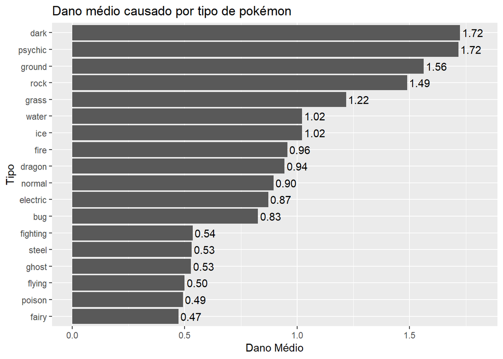

```r
dano_medio %>%
  select(type1, geral) %>%
  ggplot(aes(x = reorder(type1, geral), y = geral)) +
  geom_bar(stat = "identity") +
  coord_flip() +
  geom_text(aes(label = format(geral, digits = 2)), hjust = -0.1) +
  labs(title = "Dano médio causado por tipo de pokémon", x = "Tipo", y = "Dano Médio") +
  ylim(0, 1.8)
```

Podemos dotar que o Pokémon tipo Noturno e Psíquico possui o maior dano médio e o Fada e Veneno são os mais fraquinhos.

Lembrando que na geração 1 não existe nenhum pokémon noturno e que o Mew e Mewto são psíquicos.

É isso, espero que tenham gostado dessa aventura!!! Até mais!